# TMRC2 202402: Data Set Creation

atb abelew@gmail.com

2024-02-21

# 1 TODO

1. Have a set where we merge 2.1/2.2, 2.3/2.4.
2. Represent the transition from a global view of the samples without any classification, then state the subpopulations/zymodemes, then add sensitivity/resistance, then cure/fail.
3. Perhaps make an explicit plot where all samples are one color excepting a relatively small number of previously assayed set? The samples which would be colored in this view would be from Olga’s 2014 paper I think.
4. Make a flow diagram going from s/r -> subpopulation -> c/f/u. (sankey)
5. Make a table similar to the TMRC3 containing the statuses of the samples.
6. Explicitly consider metadata column ‘P’ for reference strains – make an all grey plot with a few samples colored taken from this column.

# 2 Changelog

## 2.1 20230524/20230628

- Frozen metadata, now using sample sheet ‘ClinicalStrains_TMRC2_Frozen 21062023.xlsx’

## 2.2 20230410

- Updating the version number due to some moderately intrusive changes I made in order to more carefully create plots of the differential expresison data. I don’t think anything I did should actually change any of the data, but some of the analyses are definitely affected (note that the only change in results is due to a mistake I made in defining one of the contrasts, all other changes are just plot aesthetic improvements)

## 2.3 20230205

- Did the stuff on this morning’s TODO which came out of this morning’s meeting: do a PCA without the oddball strains (already done in the worksheet), highlight reference strains, and add L.major IDs and Descriptions (done by appending a collapsed version of the ortholog data to the all_lp_annot data).
- Fixed human IDs for the macrophage data.
- Changed input metadata sheets: primarily because I only remembered yesterday to finish the SL search for samples >TMRC20095. They are running now and will be added momentarily (I will have to redownload the sheet).
- Setting up to make a hclust/phylogenetic tree of strains, use these are reference: 2168(2.3), 2272(2.2), for other 2.x choose arbitrarily (lower numbers are better).
- Added another sanitize columns call for Antimony vs. antimony and None vs. none in the TMRC2 macrophage samples.

# 3 Introduction

This document is intended to create the data structures used to evaluate our TMRC2 samples. In some cases, this includes only those samples starting in 2019; in other instances I am including our previous (2015-2016) samples.

In all cases the processing performed was:

1. Default trimming was performed.
2. Hisat2 was used to map the remaining reads against the Leishmania panamensis genome revision 36.
3. The alignments from hisat2 were used to count reads/gene against the revision 36 annotations with htseq.
4. These alignments were also passed to the pileup functionality of samtools and the vcf/bcf utilities in order to make a matrix of all observed differences between each sample with respect to the reference.
5. The freebayes variant estimation tool was used in addition to #4 to search for variant positions in a more robust fashion.
6. The trimmed reads were passed to kraken2 using a viral database in order to look for samples with potential LRV sequence.
7. An explicit, grep-based search for spliced leader reads was used against all human-derived samples. The results from this were copy/pasted into the sample sheet.

# 4 Notes 20221206 meeting

I am thinking that this meeting will bring Maria Adelaida fully back into the analyses of the parasite data, and therefore may focus primarily on the goals rather than the analyses?

- Maria Adelaida meeting with Olgla/Mariana: integrating transcriptomics/genomics question.
- Paper on relationship btwn primary metadata factors via transcriptome/genome.
- Second on drug susceptibility without those factors (I think this means the macrophages)
- Definition of species? MAG: Define consensus sequences for various strains/species. We effectively have this on hand, though the quality may be a little less good for 2.3.
- Resulting goal: Create a tree of the strains (I am just going to call zymodemes strains from now on). ** What organisms would we include in a tree to describe these relationships: guyanensis, braziliensis 2904, 2.2, 2.3, 2.1, 2.4, panamensis reference, peruviania(sp? I have not seen this genome), panama, 2903; actually this may be tricky because we have always done this with a specific reference strain (panamensis col) which is one of the strains in the comparison. hmm… ** Check the most variant strains for identity (Luc) ** Methods for creating tree, traditional phylogeny vs. variant hclust?
- PCR queries, works well if one performs sanger sequencing.

## 4.1 Multiple datasets

In a couple of important ways the TMRC2 data is much more complex than the TMRC3:

1. It comprises multiple, completely separate queries:
   1. Sequencing the parasite samples
   2. Sequencing a set of human macrophage samples which were infected with specific parasite samples.
2. The parasite transcriptomic samples comprise multiple different types of queries:
   1. Differential expression to look at strain, susceptibility, and clinical outcomes.
   2. Individual variant searches to look for potentially useful SNPs for classification of parasite samples.
3. The human macrophage samples may be used to query both the host and parasite transcriptomes because (at least when not drug treated) there is a tremendous population of parasite reads in them.

## 4.2 Sample sheet(s)

Our shared online sample sheet is nearly static at the time of this writing (202209), I expect at this point the only likely updates will be to annotate some strains as more or less susceptible to drug treatment.

```r
sample_sheet <- "sample_sheets/tmrc2_samples_pruned.xlsx"
macrophage_sheet <- "sample_sheets/tmrc2_macrophage_samples.xlsx"
```

# 5 Annotations

Everything which follows depends on the Existing TriTrypDB annotations revision 46, circa 2019. The following block loads a database of these annotations and turns it into a matrix where the rows are genes and columns are all the annotation types provided by TriTrypDB.

The same database was used to create a matrix of orthologous genes between L.panamensis and all of the other species in the TriTrypDB.

The same database of annotations also provides mappings to the set of annotated GO categories for the L.panamensis genome along with gene lengths.

```r
meta <- download_eupath_metadata(webservice = "tritrypdb", eu_version = "v46")
```

[output not shown]

```
## Working on: 1: org.Tvivax.Y486.v46.eg.db.
```

```
## Working on: 2: org.Tcongolense.IL3000.v46.eg.db.
```

```
## Working on: 3: org.Laethiopica.L147.v46.eg.db.
```

```
## Working on: 4: org.Ltropica.L590.v46.eg.db.
```

```
## Working on: 5: org.Tcruzi.Tula.cl2.v46.eg.db.
```

```
## Working on: 6: org.Lpanamensis.MHOMCOL81L13.v46.eg.db.
```

```
## Working on: 7: org.Lbraziliensis.MHOMBR75M2903.v46.eg.db.
```

```
## Working on: 8: org.Tcruzi.Dm28c.2014.v46.eg.db.
```

```
## Working on: 9: org.Tbrucei.brucei.TREU927.v46.eg.db.
```

[output not shown]

```
## Found an exact match for the combination genus/species/strain.
```

[output not shown]

```
## Working on: 10: org.Lmajor.Friedlin.v46.eg.db.
```

[output not shown]

```
## Found an exact match for the combination genus/species not strain for Leishmania major.
```

```
## Found more than one taxonomy ID match, returning the first match.
```

```
## Working on: 11: org.Tcruzi.CL.Brener.v46.eg.db.
```

```
## Working on: 12: org.Tcruzi.Esmeraldo.v46.eg.db.
```

```
## Found 536 candidate genera matching Trypanosoma
```

```
## Found an exact match for the combination genus/species/strain.
```

```
## Found more than one taxonomy ID match, returning the first match.
```

```
## Working on: 13: org.Lbraziliensis.MHOMBR75M2904.v46.eg.db.
```

```
## Working on: 14: org.Trangeli.SC58.v46.eg.db.
```

```
## Working on: 15: org.Linfantum.JPCM5.v46.eg.db.
```

```
## Working on: 16: org.Tbrucei.gambiense.DAL972.v46.eg.db.
```

```
## Working on: 17: org.Lmajor.LV39c5.v46.eg.db.
```

```
## Working on: 18: org.Lmajor.SD.75.1.v46.eg.db.
```

```
## Working on: 19: org.Tcruzi.JR.cl.4.v46.eg.db.
```

```
## Working on: 20: org.Lmexicana.MHOMGT2001U1103.v46.eg.db.
```

```
## Working on: 21: org.Ldonovani.BPK282A1.v46.eg.db.
```

```
## Working on: 22: org.Adeanei.Cavalho.ATCC.PRA.265.v46.eg.db.
```

```
## Found 4 candidate genera matching Angomonas
```

```
## Found an exact match for the combination genus/species not strain for Angomonas deanei.
```

```
## Found more than one taxonomy ID match, returning the first match.
```

```
## Working on: 23: org.Bayalai.B08.376.v46.eg.db.
```

```
## Found 20 candidate genera matching Blechomonas
```

```
## Found an exact match for the combination genus/species not strain for Blechomonas ayalai.
```

```
## Found more than one taxonomy ID match, returning the first match.
```

```
## Working on: 24: org.Bnonstop.P57.v46.eg.db.
```

```
## Found 28 candidate genera matching Blastocrithidia
```

```
## Found a genus, but not species for Blastocrithidia nonstop P57, not adding taxon ID number.
```

```
## Working on: 25: org.Bsaltans.Lake.Konstanz.v46.eg.db.
```

```
## Found 28 candidate genera matching Bodo
```

```
## Found an exact match for the combination genus/species not strain for Bodo saltans.
```

```
## Working on: 26: org.Cfasciculata.Cf.Cl.v46.eg.db.
```

```
## Found 52 candidate genera matching Crithidia
```

```
## Found an exact match for the combination genus/species not strain for Crithidia fasciculata.
```

```
## Working on: 27: org.Emonterogeii.LV88.v46.eg.db.
```

```
## Found 13 candidate genera matching Endotrypanum
```

```
## Found an exact match for the combination genus/species not strain for Endotrypanum monterogeii.
```

```
## Found more than one taxonomy ID match, returning the first match.
```

```
## Working on: 28: org.Lamazonensis.MHOMBR71973M2269.v46.eg.db.
```

[output not shown]

```
## Found an exact match for the combination genus/species not strain for Leishmania amazonensis.
```

```
## Found more than one taxonomy ID match, returning the first match.
```

```
## Working on: 29: org.Larabica.LEM1108.v46.eg.db.
```

```
## Found 278 candidate genera matching Leishmania
```

```
## Found an exact match for the combination genus/species not strain for Leishmania arabica.
```

```
## Working on: 30: org.Lbraziliensis.MHOMBR75M2904.2019.v46.eg.db.
```

```
## Found 278 candidate genera matching Leishmania
```

```
## Found an exact match for the combination genus/species not strain for Leishmania braziliensis.
```

```
## Found more than one taxonomy ID match, returning the first match.
```

```
## Working on: 31: org.Ldonovani.BHU.1220.v46.eg.db.
```

```
## Found 278 candidate genera matching Leishmania
```

```
## Found an exact match for the combination genus/species not strain for Leishmania donovani.
```

```
## Found more than one taxonomy ID match, returning the first match.
```

```
## Working on: 32: org.Ldonovani.CL.SL.v46.eg.db.
```

```
## Found 278 candidate genera matching Leishmania
```

```
## Found an exact match for the combination genus/species not strain for Leishmania donovani.
```

```
## Found more than one taxonomy ID match, returning the first match.
```

```
## Working on: 33: org.Ldonovani.HU3.v46.eg.db.
```

```
## Found 278 candidate genera matching Leishmania
```

```
## Found an exact match for the combination genus/species not strain for Leishmania donovani.
```

```
## Found more than one taxonomy ID match, returning the first match.
```

```
## Working on: 34: org.Ldonovani.LV9.v46.eg.db.
```

```
## Found 278 candidate genera matching Leishmania
```

```
## Found an exact match for the combination genus/species not strain for Leishmania donovani.
```

```
## Found more than one taxonomy ID match, returning the first match.
```

```
## Working on: 35: org.Lenriettii.LEM3045.v46.eg.db.
```

```
## Found 278 candidate genera matching Leishmania
```

```
## Found an exact match for the combination genus/species not strain for Leishmania enriettii.
```

```
## Found more than one taxonomy ID match, returning the first match.
```

```
## Working on: 36: org.Lenriettii.MCAVBR2001CUR178.v46.eg.db.
```

```
## Found 278 candidate genera matching Leishmania
```

```
## Found an exact match for the combination genus/species not strain for Leishmania enriettii.
```

```
## Found more than one taxonomy ID match, returning the first match.
```

```
## Working on: 37: org.Lgerbilli.LEM452.v46.eg.db.
```

```
## Found 278 candidate genera matching Leishmania
```

```
## Found an exact match for the combination genus/species not strain for Leishmania gerbilli.
```

```
## Found more than one taxonomy ID match, returning the first match.
```

```
## Working on: 38: org.Lmajor.Friedlin.2021.v46.eg.db.
```

```
## Found 278 candidate genera matching Leishmania
```

```
## Found an exact match for the combination genus/species not strain for Leishmania major.
```

```
## Found more than one taxonomy ID match, returning the first match.
```

```
## Working on: 39: org.Lmartiniquensis.LEM2494.v46.eg.db.
```

```
## Found 278 candidate genera matching Leishmania
```

```
## Found an exact match for the combination genus/species not strain for Leishmania martiniquensis.
```

```
## Found more than one taxonomy ID match, returning the first match.
```

```
## Working on: 40: org.Lmartiniquensis.MHOMTH2012LSCM1.v46.eg.db.
```

```
## Found 278 candidate genera matching Leishmania
```

```
## Found an exact match for the combination genus/species not strain for Leishmania martiniquensis.
```

```
## Found more than one taxonomy ID match, returning the first match.
```

```
## Working on: 41: org.Lorientalis.MHOMTH2014LSCM4.v46.eg.db.
```

```
## Found 278 candidate genera matching Leishmania
```

```
## Found an exact match for the combination genus/species not strain for Leishmania orientalis.
```

```
## Found more than one taxonomy ID match, returning the first match.
```

```
## Working on: 42: org.Lpanamensis.MHOMPA94PSC.1.v46.eg.db.
```

```
## Found 278 candidate genera matching Leishmania
```

```
## Found an exact match for the combination genus/species not strain for Leishmania panamensis.
```

```
## Found more than one taxonomy ID match, returning the first match.
```

```
## Working on: 43: org.Lpyrrhocoris.H10.v46.eg.db.
```

```
## Found 66 candidate genera matching Leptomonas
```

```
## Found an exact match for the combination genus/species not strain for Leptomonas pyrrhocoris.
```

```
## Found more than one taxonomy ID match, returning the first match.
```

```
## Working on: 44: org.Lseymouri.ATCC.30220.v46.eg.db.
```

```
## Found 66 candidate genera matching Leptomonas
```

```
## Found an exact match for the combination genus/species not strain for Leptomonas seymouri.
```

```
## Working on: 45: org.Lsp.Ghana.MHOMGH2012GH5.v46.eg.db.
```

```
## Found 278 candidate genera matching Leishmania
```

```
## Found an exact match for the combination genus/species not strain for Leishmania sp..
```

```
## Working on: 46: org.Lsp.Namibia.MPRONA1975252LV425.v46.eg.db.
```

```
## Found 278 candidate genera matching Leishmania
```

```
## Found an exact match for the combination genus/species not strain for Leishmania sp..
```

```
## Working on: 47: org.Ltarentolae.Parrot.TarII.v46.eg.db.
```

```
## Found 278 candidate genera matching Leishmania
```

```
## Found an exact match for the combination genus/species not strain for Leishmania tarentolae.
```

```
## Found more than one taxonomy ID match, returning the first match.
```

```
## Working on: 48: org.Ltarentolae.Parrot.Tar.II.2019.v46.eg.db.
```

```
## Found 278 candidate genera matching Leishmania
```

```
## Found an exact match for the combination genus/species not strain for Leishmania tarentolae.
```

```
## Found more than one taxonomy ID match, returning the first match.
```

```
## Working on: 49: org.Lturanica.LEM423.v46.eg.db.
```

```
## Found 278 candidate genera matching Leishmania
```

```
## Found an exact match for the combination genus/species not strain for Leishmania turanica.
```

```
## Working on: 50: org.Pconfusum.CUL13.v46.eg.db.
```

```
## Found 4 candidate genera matching Paratrypanosoma
```

```
## Found an exact match for the combination genus/species not strain for Paratrypanosoma confusum.
```

```
## Found more than one taxonomy ID match, returning the first match.
```

```
## Working on: 51: org.Phertigi.MCOEPA1965C119.v46.eg.db.
```

```
## Found 3 candidate genera matching Porcisia
```

```
## Found an exact match for the combination genus/species not strain for Porcisia hertigi.
```

```
## Working on: 52: org.Tbrucei.EATRO1125.v46.eg.db.
```

[output not shown]

```
## Found an exact match for the combination genus/species not strain for Trypanosoma brucei.
```

```
## Found more than one taxonomy ID match, returning the first match.
```

```
## Working on: 53: org.Tbrucei.Lister.427.v46.eg.db.
```

```
## Found 536 candidate genera matching Trypanosoma
```

```
## Found an exact match for the combination genus/species not strain for Trypanosoma brucei.
```

```
## Found more than one taxonomy ID match, returning the first match.
```

```
## Working on: 54: org.Tbrucei.Lister.427.2018.v46.eg.db.
```

```
## Found 536 candidate genera matching Trypanosoma
```

```
## Found an exact match for the combination genus/species not strain for Trypanosoma brucei.
```

```
## Found more than one taxonomy ID match, returning the first match.
```

```
## Working on: 55: org.Tcongolense.IL3000.2019.v46.eg.db.
```

```
## Found 536 candidate genera matching Trypanosoma
```

```
## Found an exact match for the combination genus/species not strain for Trypanosoma congolense.
```

```
## Working on: 56: org.Tcongolense.Tc1148.v46.eg.db.
```

```
## Found 536 candidate genera matching Trypanosoma
```

```
## Found an exact match for the combination genus/species not strain for Trypanosoma congolense.
```

```
## Working on: 57: org.Tcruzi.231.v46.eg.db.
```

[output not shown]

```
## Found an exact match for the combination genus/species not strain for Trypanosoma cruzi.
```

```
## Working on: 58: org.Tcruzi.Berenice.v46.eg.db.
```

```
## Found 536 candidate genera matching Trypanosoma
```

```
## Found an exact match for the combination genus/species not strain for Trypanosoma cruzi.
```

```
## Working on: 59: org.Tcruzi.Brazil.A4.v46.eg.db.
```

```
## Found 536 candidate genera matching Trypanosoma
```

```
## Found an exact match for the combination genus/species not strain for Trypanosoma cruzi.
```

```
## Working on: 60: org.Tcruzi.Bug2148.v46.eg.db.
```

```
## Found 536 candidate genera matching Trypanosoma
```

```
## Found an exact match for the combination genus/species not strain for Trypanosoma cruzi.
```

```
## Working on: 61: org.Tcruzi.CL.v46.eg.db.
```

```
## Found 536 candidate genera matching Trypanosoma
```

```
## Found an exact match for the combination genus/species not strain for Trypanosoma cruzi.
```

```
## Working on: 62: org.Tcruzi.CL.Brener.Esmeraldo.like.v46.eg.db.
```

```
## Found 536 candidate genera matching Trypanosoma
```

```
## Found an exact match for the combination genus/species not strain for Trypanosoma cruzi.
```

```
## Working on: 63: org.Tcruzi.CL.Brener.Non.Esmeraldo.like.v46.eg.db.
```

```
## Found 536 candidate genera matching Trypanosoma
```

```
## Found an exact match for the combination genus/species not strain for Trypanosoma cruzi.
```

```
## Working on: 64: org.Tcruzi.Dm28c.2017.v46.eg.db.
```

```
## Found 536 candidate genera matching Trypanosoma
```

```
## Found an exact match for the combination genus/species not strain for Trypanosoma cruzi.
```

```
## Working on: 65: org.Tcruzi.Dm28c.2018.v46.eg.db.
```

```
## Found 536 candidate genera matching Trypanosoma
```

```
## Found an exact match for the combination genus/species not strain for Trypanosoma cruzi.
```

```
## Working on: 66: org.Tcruzi.G.v46.eg.db.
```

```
## Found 536 candidate genera matching Trypanosoma
```

```
## Found an exact match for the combination genus/species not strain for Trypanosoma cruzi.
```

```
## Working on: 67: org.Tcruzi.S11.v46.eg.db.
```

```
## Found 536 candidate genera matching Trypanosoma
```

```
## Found an exact match for the combination genus/species not strain for Trypanosoma cruzi.
```

```
## Working on: 68: org.Tcruzi.S15.v46.eg.db.
```

```
## Found 536 candidate genera matching Trypanosoma
```

```
## Found an exact match for the combination genus/species not strain for Trypanosoma cruzi.
```

```
## Working on: 69: org.Tcruzi.S154a.v46.eg.db.
```

```
## Found 536 candidate genera matching Trypanosoma
```

```
## Found an exact match for the combination genus/species not strain for Trypanosoma cruzi.
```

```
## Working on: 70: org.Tcruzi.S162a.v46.eg.db.
```

```
## Found 536 candidate genera matching Trypanosoma
```

```
## Found an exact match for the combination genus/species not strain for Trypanosoma cruzi.
```

```
## Working on: 71: org.Tcruzi.S23b.v46.eg.db.
```

```
## Found 536 candidate genera matching Trypanosoma
```

```
## Found an exact match for the combination genus/species not strain for Trypanosoma cruzi.
```

```
## Working on: 72: org.Tcruzi.S44a.v46.eg.db.
```

```
## Found 536 candidate genera matching Trypanosoma
```

```
## Found an exact match for the combination genus/species not strain for Trypanosoma cruzi.
```

```
## Working on: 73: org.Tcruzi.S92a.v46.eg.db.
```

[output not shown]

```
## Found an exact match for the combination genus/species not strain for Trypanosoma cruzi.
```

```
## Working on: 74: org.Tcruzi.Sylvio.X101.v46.eg.db.
```

```
## Found 536 candidate genera matching Trypanosoma
```

```
## Found an exact match for the combination genus/species not strain for Trypanosoma cruzi.
```

```
## Working on: 75: org.Tcruzi.Sylvio.X101.2012.v46.eg.db.
```

```
## Found 536 candidate genera matching Trypanosoma
```

```
## Found an exact match for the combination genus/species not strain for Trypanosoma cruzi.
```

```
## Working on: 76: org.Tcruzi.TCC.v46.eg.db.
```

```
## Found 536 candidate genera matching Trypanosoma
```

```
## Found an exact match for the combination genus/species not strain for Trypanosoma cruzi.
```

```
## Working on: 77: org.Tcruzi.Y.v46.eg.db.
```

```
## Found 536 candidate genera matching Trypanosoma
```

```
## Found an exact match for the combination genus/species not strain for Trypanosoma cruzi.
```

```
## Working on: 78: org.Tcruzi.Y.C6.v46.eg.db.
```

```
## Found 536 candidate genera matching Trypanosoma
```

```
## Found an exact match for the combination genus/species not strain for Trypanosoma cruzi.
```

```
## Working on: 79: org.Tcruzi.Ycl2.v46.eg.db.
```

```
## Found 536 candidate genera matching Trypanosoma
```

```
## Found an exact match for the combination genus/species not strain for Trypanosoma cruzi.
```

```
## Working on: 80: org.Tcruzi.Ycl4.v46.eg.db.
```

```
## Found 536 candidate genera matching Trypanosoma
```

```
## Found an exact match for the combination genus/species not strain for Trypanosoma cruzi.
```

```
## Working on: 81: org.Tcruzi.Ycl6.v46.eg.db.
```

```
## Found 536 candidate genera matching Trypanosoma
```

```
## Found an exact match for the combination genus/species not strain for Trypanosoma cruzi.
```

```
## Working on: 82: org.Tcruzi.marinkellei.B7.v46.eg.db.
```

```
## Found 536 candidate genera matching Trypanosoma
```

```
## Found an exact match for the combination genus/species not strain for Trypanosoma cruzi.
```

```
## Working on: 83: org.Tequiperdum.OVI.v46.eg.db.
```

```
## Found 536 candidate genera matching Trypanosoma
```

```
## Found an exact match for the combination genus/species not strain for Trypanosoma equiperdum.
```

```
## Found more than one taxonomy ID match, returning the first match.
```

```
## Working on: 84: org.Tevansi.STIB.805.v46.eg.db.
```

```
## Found 536 candidate genera matching Trypanosoma
```

```
## Found an exact match for the combination genus/species not strain for Trypanosoma evansi.
```

```
## Found more than one taxonomy ID match, returning the first match.
```

```
## Working on: 85: org.Tgrayi.ANR4.v46.eg.db.
```

```
## Found 536 candidate genera matching Trypanosoma
```

```
## Found an exact match for the combination genus/species not strain for Trypanosoma grayi.
```

```
## Working on: 86: org.Tmelophagium.St.Kilda.v46.eg.db.
```

```
## Found 536 candidate genera matching Trypanosoma
```

```
## Found an exact match for the combination genus/species not strain for Trypanosoma melophagium.
```

```
## Working on: 87: org.Ttheileri.isolate.Edinburgh.v46.eg.db.
```

```
## Found 536 candidate genera matching Trypanosoma
```

```
## Found an exact match for the combination genus/species not strain for Trypanosoma theileri.
```

```r
panamensis_entry <- get_eupath_entry("MHOM", metadata = meta[["valid"]])
```

```
## Found the following hits: Leishmania panamensis MHOM/COL/81/L13, Leishmania braziliensis MHOM/BR/75/M2903, Leishmania braziliensis MHOM/BR/75/M2904, Leishmania mexicana MHOM/GT/2001/U1103, Leishmania sp. Ghana MHOM/GH/2012/GH5, choosing the first.
```

```
## Using: Leishmania panamensis MHOM/COL/81/L13.
```

```r
panamensis_db <- make_eupath_orgdb(panamensis_entry)
```

```
##  org.Lpanamensis.MHOMCOL81L13.v46.eg.db is already installed and a copy should be found at: /z1/sw/local/R/4.3/3.17/org.Lpanamensis.MHOMCOL81L13.v46.eg.db/extdata/org.Lpanamensis.MHOMCOL81L13.v46.eg.sqlite.
```

```r
panamensis_pkg <- panamensis_db[["pkgname"]]
package_name <- panamensis_db[["pkgname"]]
if (is.null(panamensis_pkg)) {
  panamensis_pkg <- panamensis_db[["orgdb_name"]]
  package_name <- panamensis_pkg
}
tt <- library(panamensis_pkg, character.only = TRUE)
panamensis_pkg <- get0(panamensis_pkg)
all_fields <- columns(panamensis_pkg)
all_lp_annot <- sm(load_orgdb_annotations(
    panamensis_pkg,
    keytype = "gid",
    fields = c("annot_gene_entrez_id", "annot_gene_name",
               "annot_strand", "annot_chromosome", "annot_cds_length",
               "annot_gene_product")))$genes

lp_go <- load_orgdb_go(panamensis_pkg)
```

```
## Error in as.vector(x, "character"): cannot coerce type 'environment' to vector of type 'character'
```

```r
lp_go <- lp_go[, c("GID", "GO")]
```

```
## Error in eval(expr, envir, enclos): object 'lp_go' not found
```

```r
lp_lengths <- all_lp_annot[, c("gid", "annot_cds_length")]
colnames(lp_lengths)  <- c("ID", "length")
all_lp_annot[["annot_gene_product"]] <- tolower(all_lp_annot[["annot_gene_product"]])
orthos <- sm(extract_eupath_orthologs(db = panamensis_pkg))
```

## 5.1 Repeat for the L.major annotations

Recently there was a request to include the Leishmania major gene IDs and descriptions. Thus I will extract them along with the orthologs and append that to the annotations used.

Having spent the time to run the following code, I realized that the orthologs data structure above actually already has the gene IDs and descriptions.

Thus I will leave my query in place to extract the major annotations, but follow it up with a collapse of the major orthologs and appending of that to the panamensis annotations.

```r
orgdb <- "org.Lmajor.Friedlin.v49.eg.db"
tt <- sm(library(orgdb, character.only = TRUE))
major_db <- org.Lmajor.Friedlin.v49.eg.db
all_fields <- columns(pan_db)
all_lm_annot <- sm(load_orgdb_annotations(
    major_db,
    keytype = "gid",
    fields = c("annot_gene_entrez_id", "annot_gene_name",
               "annot_strand", "annot_chromosome", "annot_cds_length",
               "annot_gene_product")))$genes

wanted_orthos_idx <- orthos[["ORTHOLOGS_SPECIES"]] == "Leishmania major strain Friedlin"
sum(wanted_orthos_idx)
wanted_orthos <- orthos[wanted_orthos_idx, ]
wanted_orthos <- wanted_orthos[, c("GID", "ORTHOLOGS_ID", "ORTHOLOGS_NAME")]

collapsed_orthos <- wanted_orthos %>%
  group_by(GID) %>%
  summarise(collapsed_id = stringr::str_c(ORTHOLOGS_ID, collapse=" ; "),
            collapsed_name = stringr::str_c(ORTHOLOGS_NAME, collapse=" ; "))
all_lp_annot <- merge(all_lp_annot, collapsed_orthos, by.x = "row.names",
                      by.y = "GID", all.x = TRUE)
rownames(all_lp_annot) <- all_lp_annot[["Row.names"]]
all_lp_annot[["Row.names"]] <- NULL
data_structures <- c(data_structures, "lp_lengths", "lp_go", "all_lp_annot")
```

# 6 Load a genome

The following block loads the full genome sequence for panamensis. We may use this later to attempt to estimate PCR primers to discern strains.

I am not sure how to increase the number of open files in a container, as a result this does not work.

```r
testing_panamensis <- make_eupath_bsgenome(entry = panamensis_entry, eu_version = "v46")
library(as.character(testing_panamensis), character.only = TRUE)
lp_genome <- get0(as.character(testing_panamensis))
data_structures <- c(data_structures, "lp_genome")
```

# 7 Generate Expressionsets and Sample Estimation

The process of sample estimation takes two primary inputs:

1. The sample sheet, which contains all the metadata we currently have on hand, including filenames for the outputs of #3 and #4 above.
2. The gene annotations.

An expressionSet(or summarizedExperiment) is a data structure used in R to examine RNASeq data. It is comprised of annotations, metadata, and expression data. In the case of our processing pipeline, the location of the expression data is provided by the filenames in the metadata.

## 7.1 Notes

The following samples are much lower coverage:

- TMRC20002
- TMRC20006
- TMRC20007
- TMRC20008

There is a set of strains which acquired resistance in vitro. These are included in the dataset, but there are not likely enough of them to query that question explicitly.

## 7.2 Define colors

The following list contains the colors we have chosen to use when plotting the various ways of discerning the data.

```r
color_choices <- list(
    "strain" = list(
        ## "z1.0" = "#333333", ## Changed this to 'braz' to make it easier to find them.
        "z2.0" = "#555555",
        "z3.0" = "#777777",
        "z2.1" = "#874400",
        "z2.2" = "#0000cc",
        "z2.3" = "#cc0000",
        "z2.4" = "#df7000",
        "z3.2" = "#888888",
        "z1.0" = "#cc00cc",
        "z1.5" = "#cc00cc",
        "b2904" = "#cc00cc",
        "unknown" = "#cbcbcb"),
    ## "null" = "#000000"),
    "zymo" = list(
      "z22" = "#0000cc",
      "z23" = "#cc0000"),
    "cf" = list(
        "cure" = "#006f00",
        "fail" = "#9dffa0",
        "unknown" = "#cbcbcb",
        "notapplicable" = "#000000"),
    "susceptibility" = list(
        "resistant" = "#8563a7",
        "sensitive" = "#8d0000",
        "ambiguous" = "#cbcbcb",
        "unknown" = "#555555"))
data_structures <- c(data_structures, "color_choices")
```

# 8 Parasite-only data structure

The data structure ‘lp_expt’ contains the data for all samples which have hisat2 count tables, and which pass a few initial quality tests (e.g. they must have more than 8550 genes with >0 counts and >5e6 reads which mapped to a gene); genes which are annotated with a few key redundant categories (leishmanolysin for example) are also culled.

## 8.1 All (almost) samples

There are a few metadata columns which we really want to make certain are standardized.

```r
sanitize_columns <- c("passagenumber", "clinicalresponse", "clinicalcategorical",
                      "zymodemecategorical")
lp_expt <- create_expt(sample_sheet,
                       gene_info = all_lp_annot,
                       annotation_name = package_name,
                       savefile = glue("rda/tmrc2_lp_expt_all_raw-v{ver}.rda"),
                       id_column = "hpglidentifier",
                       annotation = package_name, ## this is redundantredundant
                       file_column = "lpanamensisv36hisatfile") %>%
  set_expt_conditions(fact = "zymodemecategorical", colors = color_choices[["strain"]]) %>%
  subset_expt(nonzero = 8550) %>%
  subset_expt(coverage = 5000000) %>%
  semantic_expt_filter(semantic = c("amastin", "gp63", "leishmanolysin"),
                       semantic_column = "annot_gene_product") %>%
  sanitize_expt_pData(columns = sanitize_columns) %>%
  set_expt_factors(columns = sanitize_columns, class = "factor")
```

```
## Reading the sample metadata.
```

```
## Dropped 11 rows from the sample metadata because the sample ID is blank.
```

```
## Did not find the condition column in the sample sheet.
```

```
## Filling it in as undefined.
```

```
## Did not find the batch column in the sample sheet.
```

```
## Filling it in as undefined.
```

```
## The sample definitions comprises: 110 rows(samples) and 72 columns(metadata fields).
```

[output not shown]

```r
data_structures <- c(data_structures, "lp_expt")
save(list = "lp_expt", file = glue("rda/tmrc2_lp_expt_all_sanitized-v{ver}.rda"))
```

```
## Error in save(list = "lp_expt", file = glue("rda/tmrc2_lp_expt_all_sanitized-v{ver}.rda")): object 'lp_expt' not found
```

```r
table(pData(lp_expt)[["zymodemecategorical"]])
```

```
## Error in h(simpleError(msg, call)): error in evaluating the argument 'object' in selecting a method for function 'pData': object 'lp_expt' not found
```

```r
table(pData(lp_expt)[["clinicalresponse"]])
```

```
## Error in h(simpleError(msg, call)): error in evaluating the argument 'object' in selecting a method for function 'pData': object 'lp_expt' not found
```

```r
ncol(exprs(lp_expt))
```

```
## Error in h(simpleError(msg, call)): error in evaluating the argument 'x' in selecting a method for function 'ncol': error in evaluating the argument 'object' in selecting a method for function 'exprs': object 'lp_expt' not found
```

All the following data will derive from this starting point.

## 8.2 Extract historical susceptibility data

Column ‘Q’ in the sample sheet, make a categorical version of it with these parameters:

- 0 <= x <= 35 is resistant
- 36 <= x <= 48 is ambiguous
- 49 <= x is sensitive

```r
max_resist_historical <- 0.35
min_sensitive_historical <- 0.49

## 202305: Removed ambiguous category for the current set.g
max_resist_current <- 0.76
min_sensitive_current <- 0.77
```

The sanitize_percent() function seeks to make the percentage values recorded by excel more reliable. Unfortunately, sometimes excel displays the value ‘49%’ when the information recorded in the worksheet is any one of the following:

- ’49%
- 0.49
- “0.49”

Thus, the following block will sanitize these percentage values into a single decimal number and make a categorical variable from it using pre-defined values for resistant/ambiguous/sensitive. This categorical variable will be stored in a new column: ‘sus_category_historical’.

```r
st <- pData(lp_expt)[["susceptibilityinfectionreduction32ugmlsbvhistoricaldata"]]
```

```
## Error in h(simpleError(msg, call)): error in evaluating the argument 'object' in selecting a method for function 'pData': object 'lp_expt' not found
```

```r
starting <- sanitize_percent(st)
```

```
## Error in eval(expr, envir, enclos): object 'st' not found
```

```r
st
```

```
## Error in eval(expr, envir, enclos): object 'st' not found
```

```r
starting
```

```
## Error in eval(expr, envir, enclos): object 'starting' not found
```

```r
sus_categorical <- starting
```

```
## Error in eval(expr, envir, enclos): object 'starting' not found
```

```r
na_idx <- is.na(starting)
```

```
## Error in eval(expr, envir, enclos): object 'starting' not found
```

```r
sum(na_idx)
```

```
## Error in eval(expr, envir, enclos): object 'na_idx' not found
```

```r
sus_categorical[na_idx] <- "unknown"
```

```
## Error: object 'sus_categorical' not found
```

```r
resist_idx <- starting <= max_resist_historical
```

```
## Error in eval(expr, envir, enclos): object 'starting' not found
```

```r
sus_categorical[resist_idx] <- "resistant"
```

```
## Error: object 'sus_categorical' not found
```

```r
indeterminant_idx <- starting > max_resist_historical &
  starting < min_sensitive_historical
```

```
## Error in eval(expr, envir, enclos): object 'starting' not found
```

```r
sus_categorical[indeterminant_idx] <- "ambiguous"
```

```
## Error: object 'sus_categorical' not found
```

```r
susceptible_idx <- starting >= min_sensitive_historical
```

```
## Error in eval(expr, envir, enclos): object 'starting' not found
```

```r
sus_categorical[susceptible_idx] <- "sensitive"
```

```
## Error: object 'sus_categorical' not found
```

```r
sus_categorical <- as.factor(sus_categorical)
```

```
## Error in h(simpleError(msg, call)): error in evaluating the argument 'x' in selecting a method for function 'as.factor': object 'sus_categorical' not found
```

```r
pData(lp_expt)[["sus_category_historical"]] <- sus_categorical
```

```
## Error in eval(expr, envir, enclos): object 'sus_categorical' not found
```

```r
table(sus_categorical)
```

```
## Error in eval(expr, envir, enclos): object 'sus_categorical' not found
```

## 8.3 Extract current susceptibility data

The same process will be repeated for the current iteration of the sensitivity assay and stored in the ‘sus_category_current’ column.

```r
starting_current <- sanitize_percent(pData(lp_expt)[["susceptibilityinfectionreduction32ugmlsbvcurrentdata"]])
```

```
## Error in h(simpleError(msg, call)): error in evaluating the argument 'object' in selecting a method for function 'pData': object 'lp_expt' not found
```

```r
sus_categorical_current <- starting_current
```

```
## Error in eval(expr, envir, enclos): object 'starting_current' not found
```

```r
na_idx <- is.na(starting_current)
```

```
## Error in eval(expr, envir, enclos): object 'starting_current' not found
```

```r
sum(na_idx)
```

```
## Error in eval(expr, envir, enclos): object 'na_idx' not found
```

```r
sus_categorical_current[na_idx] <- "unknown"
```

```
## Error: object 'sus_categorical_current' not found
```

```r
resist_idx <- starting_current <= max_resist_current
```

```
## Error in eval(expr, envir, enclos): object 'starting_current' not found
```

```r
sus_categorical_current[resist_idx] <- "resistant"
```

```
## Error: object 'sus_categorical_current' not found
```

```r
indeterminant_idx <- starting_current > max_resist_current &
  starting_current < min_sensitive_current
```

```
## Error in eval(expr, envir, enclos): object 'starting_current' not found
```

```r
sus_categorical_current[indeterminant_idx] <- "ambiguous"
```

```
## Error: object 'sus_categorical_current' not found
```

```r
susceptible_idx <- starting_current >= min_sensitive_current
```

```
## Error in eval(expr, envir, enclos): object 'starting_current' not found
```

```r
sus_categorical_current[susceptible_idx] <- "sensitive"
```

```
## Error: object 'sus_categorical_current' not found
```

```r
sus_categorical_current <- as.factor(sus_categorical_current)
```

```
## Error in h(simpleError(msg, call)): error in evaluating the argument 'x' in selecting a method for function 'as.factor': object 'sus_categorical_current' not found
```

```r
pData(lp_expt)[["sus_category_current"]] <- sus_categorical_current
```

```
## Error in eval(expr, envir, enclos): object 'sus_categorical_current' not found
```

```r
pData(lp_expt)[["susceptibility"]] <- sus_categorical_current
```

```
## Error in eval(expr, envir, enclos): object 'sus_categorical_current' not found
```

```r
table(sus_categorical_current)
```

```
## Error in eval(expr, envir, enclos): object 'sus_categorical_current' not found
```

```r
lp_sankey <- plot_meta_sankey(
  lp_expt, factors = c("zymodemecategorical", "clinicalcategorical", "susceptibility"),
  drill_down = TRUE, color_choices = color_choices)
```

```
## Error in h(simpleError(msg, call)): error in evaluating the argument 'design' in selecting a method for function 'plot_meta_sankey': object 'lp_expt' not found
```

```r
lp_sankey
```

```
## Error in eval(expr, envir, enclos): object 'lp_sankey' not found
```

## 8.4 Extract samples from only the two ‘canonical’ strains

### 8.4.1 Quick divergence

```r
table(pData(lp_expt)[["knnv2classification"]])
```

```
## Error in h(simpleError(msg, call)): error in evaluating the argument 'object' in selecting a method for function 'pData': object 'lp_expt' not found
```

### 8.4.2 Merge 2.1/2.2 and 2.4/2.3

```r
merged_zymo <- lp_expt
```

```
## Error in eval(expr, envir, enclos): object 'lp_expt' not found
```

```r
pData(merged_zymo)[["zymodeme"]] <- as.character(pData(merged_zymo)[["zymodemecategorical"]])
```

```
## Error in h(simpleError(msg, call)): error in evaluating the argument 'object' in selecting a method for function 'pData': object 'merged_zymo' not found
```

```r
z21_idx <- pData(merged_zymo)[["zymodeme"]] == "z21"
```

```
## Error in h(simpleError(msg, call)): error in evaluating the argument 'object' in selecting a method for function 'pData': object 'merged_zymo' not found
```

```r
pData(merged_zymo)[z21_idx, "zymodeme"] <- "z22"
```

```
## Error: object 'merged_zymo' not found
```

```r
z24_idx <- pData(merged_zymo)[["zymodeme"]] == "z24"
```

```
## Error in h(simpleError(msg, call)): error in evaluating the argument 'object' in selecting a method for function 'pData': object 'merged_zymo' not found
```

```r
pData(merged_zymo)[z24_idx, "zymodeme"] <- "z23"
```

```
## Error: object 'merged_zymo' not found
```

```r
keepers <- pData(merged_zymo)[["zymodeme"]] == "z22" |
  pData(merged_zymo)[["zymodeme"]] == "z23"
```

```
## Error in h(simpleError(msg, call)): error in evaluating the argument 'object' in selecting a method for function 'pData': object 'merged_zymo' not found
```

```r
merged_zymo <- merged_zymo[, keepers] %>%
  set_expt_conditions(fact = "zymodeme", colors = color_choices[["zymo"]])
```

```
## Error in h(simpleError(msg, call)): error in evaluating the argument 'object' in selecting a method for function 'pData': object 'merged_zymo' not found
```

```r
two_sankey <- plot_meta_sankey(
  merged_zymo, factors = c("zymodeme", "clinicalcategorical", "susceptibility"),
  drill_down = TRUE, color_choices = color_choices)
```

```
## Error in h(simpleError(msg, call)): error in evaluating the argument 'design' in selecting a method for function 'plot_meta_sankey': object 'merged_zymo' not found
```

```r
two_sankey
```

```
## Error in eval(expr, envir, enclos): object 'two_sankey' not found
```

```r
lp_strain <- lp_expt %>%
  set_expt_batches(fact = sus_categorical_current) %>%
  set_expt_colors(color_choices[["strain"]])
```

```
## Error in h(simpleError(msg, call)): error in evaluating the argument 'object' in selecting a method for function 'pData': error in evaluating the argument 'object' in selecting a method for function 'pData': object 'lp_expt' not found
```

```r
table(pData(lp_strain)[["condition"]])
```

```
## Error in h(simpleError(msg, call)): error in evaluating the argument 'object' in selecting a method for function 'pData': object 'lp_strain' not found
```

```r
save(list = "lp_strain", file = glue("rda/tmrc2_lp_strain-v{ver}.rda"))
```

```
## Error in save(list = "lp_strain", file = glue("rda/tmrc2_lp_strain-v{ver}.rda")): object 'lp_strain' not found
```

```r
data_structures <- c(data_structures, "lp_strain")

lp_two_strains <- merged_zymo
```

```
## Error in eval(expr, envir, enclos): object 'merged_zymo' not found
```

```r
save(list = "lp_two_strains",
     file = glue("rda/tmrc2_lp_two_strains-v{ver}.rda"))
```

```
## Error in save(list = "lp_two_strains", file = glue("rda/tmrc2_lp_two_strains-v{ver}.rda")): object 'lp_two_strains' not found
```

```r
data_structures <- c(data_structures, "lp_two_strains")
```

## 8.5 Clinical outcome

Clinical outcome is by far the most problematic comparison in this data, but here is the recategorization of the data using it:

```r
lp_cf <- set_expt_conditions(lp_expt, fact = "clinicalcategorical",
                             colors = color_choices[["cf"]]) %>%
  set_expt_batches(fact = sus_categorical_current)
```

```
## Error in h(simpleError(msg, call)): error in evaluating the argument 'object' in selecting a method for function 'pData': error in evaluating the argument 'object' in selecting a method for function 'pData': object 'lp_expt' not found
```

```r
table(pData(lp_cf)[["condition"]])
```

```
## Error in h(simpleError(msg, call)): error in evaluating the argument 'object' in selecting a method for function 'pData': object 'lp_cf' not found
```

```r
data_structures <- c(data_structures, "lp_cf")
save(list = "lp_cf",
     file = glue("rda/tmrc2_lp_cf-v{ver}.rda"))
```

```
## Error in save(list = "lp_cf", file = glue("rda/tmrc2_lp_cf-v{ver}.rda")): object 'lp_cf' not found
```

```r
lp_cf_known <- subset_expt(lp_cf, subset="condition!='unknown'")
```

```
## Error in h(simpleError(msg, call)): error in evaluating the argument 'expt' in selecting a method for function 'subset_expt': object 'lp_cf' not found
```

```r
data_structures <- c(data_structures, "lp_cf_known")
save(list = "lp_cf_known",
     file = glue("rda/tmrc2_lp_cf_known-v{ver}.rda"))
```

```
## Error in save(list = "lp_cf_known", file = glue("rda/tmrc2_lp_cf_known-v{ver}.rda")): object 'lp_cf_known' not found
```

## 8.6 Create a historical susceptibility dataset

Use the factorized version of susceptibility to categorize the samples by the historical data.

```r
lp_susceptibility_historical <- set_expt_conditions(
  lp_expt, fact = "sus_category_historical", colors = color_choices[["susceptibility"]]) %>%
  set_expt_batches(fact = "clinicalcategorical")
```

```
## Error in h(simpleError(msg, call)): error in evaluating the argument 'object' in selecting a method for function 'pData': error in evaluating the argument 'object' in selecting a method for function 'pData': object 'lp_expt' not found
```

```r
save(list = "lp_susceptibility_historical",
     file = glue("rda/tmrc2_lp_susceptibility_historical-v{ver}.rda"))
```

```
## Error in save(list = "lp_susceptibility_historical", file = glue("rda/tmrc2_lp_susceptibility_historical-v{ver}.rda")): object 'lp_susceptibility_historical' not found
```

```r
data_structures <- c(data_structures, "lp_susceptibility_historical")
```

## 8.7 Create a current susceptibility dataset

This will likely be our canonical susceptibility dataset, so I will remove the suffix and just call it ‘lp_susceptibility’.

```r
lp_susceptibility <- set_expt_conditions(
  lp_expt, fact = "sus_category_current", colors = color_choices[["susceptibility"]]) %>%
  set_expt_batches(fact = "clinicalcategorical")
```

```
## Error in h(simpleError(msg, call)): error in evaluating the argument 'object' in selecting a method for function 'pData': error in evaluating the argument 'object' in selecting a method for function 'pData': object 'lp_expt' not found
```

```r
save(list = "lp_susceptibility",
     file = glue("rda/tmrc2_lp_susceptibility-v{ver}.rda"))
```

```
## Error in save(list = "lp_susceptibility", file = glue("rda/tmrc2_lp_susceptibility-v{ver}.rda")): object 'lp_susceptibility' not found
```

```r
data_structures <- c(data_structures, "lp_susceptibility")
```

## 8.8 Pull out only the samples with two zymodemes

I think this is redundant with a previous block, but I am leaving it until I am certain that it is not required in a following document.

```r
lp_zymo <- subset_expt(lp_expt, subset = "condition=='z2.2'|condition=='z2.3'")
```

```
## Error in h(simpleError(msg, call)): error in evaluating the argument 'expt' in selecting a method for function 'subset_expt': object 'lp_expt' not found
```

```r
data_structures <- c(data_structures, "lp_zymo")
save(list = "lp_zymo",
     file = glue("rda/tmrc2_lp_zymo-v{ver}.rda"))
```

```
## Error in save(list = "lp_zymo", file = glue("rda/tmrc2_lp_zymo-v{ver}.rda")): object 'lp_zymo' not found
```

# 9 Variant data using parasite RNASeq reads

The following section will create some initial data structures of the observed variants in the parasite samples. This will include some of our 2016 samples for some classification queries.

## 9.1 The 2016 variant data

I changed and improved the mapping and variant detection methods from what we used for the 2016 data. So some small changes will be required to merge them.

```r
lp_previous <- create_expt("sample_sheets/tmrc2_samples_20191203.xlsx",
                           file_column = "tophat2file",
                           savefile = glue("rda/lp_previous-v{ver}.rda"))
tt <- lp_previous$expressionset
rownames(tt) <- gsub(pattern = "^exon_", replacement = "", x = rownames(tt))
rownames(tt) <- gsub(pattern = "\\.1$", replacement = "", x = rownames(tt))
rownames(tt) <- gsub(pattern = "\\-1$", replacement = "", x = rownames(tt))
lp_previous$expressionset <- tt
rm(tt)
data_structures <- c(data_structures, "lp_previous")
```

## 9.2 Create the SNP expressionset

The count_expt_snps() function uses our expressionset data and a metadata column in order to extract the mpileup or freebayes-based variant calls and create matrices of the likelihood that each position-per-sample is in fact a variant.

There is an important caveat here which changed on 202301: I was interpreting using the PAIRED tag, which is only used for, unsurprisingly, paired-end samples. A couple samples are not paired and so were failing silently. The QA tag looks like it is more appropriate and should work across both types. One way to find out, I am setting it here and will look to see if the results make more sense for my test samples (TMRC2001, TMRC2005, TMRC2007).

```r
## The next line drops the samples which are missing the SNP pipeline.
lp_snp <- subset_expt(lp_expt, subset = "!is.na(pData(lp_expt)[['freebayessummary']])")
```

```
## Error in h(simpleError(msg, call)): error in evaluating the argument 'expt' in selecting a method for function 'subset_expt': object 'lp_expt' not found
```

```r
new_snps <- count_expt_snps(lp_snp, annot_column = "freebayessummary", snp_column = "QA")
```

```
## Error in h(simpleError(msg, call)): error in evaluating the argument 'object' in selecting a method for function 'pData': object 'lp_snp' not found
```

```r
## Lets see if we get numbers which make sense.
summary(exprs(new_snps)[["tmrc20001"]])  ## My weirdo sample
```

```
## Error in h(simpleError(msg, call)): error in evaluating the argument 'object' in selecting a method for function 'summary': error in evaluating the argument 'object' in selecting a method for function 'exprs': object 'new_snps' not found
```

```r
summary(exprs(new_snps)[["tmrc20072"]])  ## Another sample chosen at random
```

```
## Error in h(simpleError(msg, call)): error in evaluating the argument 'object' in selecting a method for function 'summary': error in evaluating the argument 'object' in selecting a method for function 'exprs': object 'new_snps' not found
```

```r
summary(exprs(new_snps)[["tmrc20021"]])  ## Another sample chosen at random
```

```
## Error in h(simpleError(msg, call)): error in evaluating the argument 'object' in selecting a method for function 'summary': error in evaluating the argument 'object' in selecting a method for function 'exprs': object 'new_snps' not found
```

```r
## Now that we are reasonably confident that things make more sense, lets save and move on...
data_structures <- c(data_structures, "new_snps")

tt <- normalize_expt(new_snps, transform = "log2")
```

```
## Error in h(simpleError(msg, call)): error in evaluating the argument 'expt' in selecting a method for function 'normalize_expt': object 'new_snps' not found
```

```r
plot_boxplot(tt)
```

```
## Error in plot_boxplot(tt): This function understands types: expt, ExpressionSet, data.frame, and matrix.
```

Now let us pull in the 2016 data.

```r
old_snps <- count_expt_snps(lp_previous, annot_column = "bcftable", snp_column = 2)
data_structures <- c(data_structures, "old_snps")

save(list = "lp_snp",
     file = glue("rda/lp_snp-v{ver}.rda"))
data_structures <- c(data_structures, "lp_snp")
save(list = "new_snps",
     file = glue("rda/new_snps-v{ver}.rda"))
data_structures <- c(data_structures, "new_snps")
save(list = "old_snps",
     file = glue("rda/old_snps-v{ver}.rda"))
data_structures <- c(data_structures, "old_snps")

nonzero_snps <- exprs(new_snps) != 0
colSums(nonzero_snps)
```

## 9.3 Combine the previous and current data

As far as I can tell, freebayes and mpileup are reasonably similar in their sensitivity/specificity; so combining the two datasets like this is expected to work with minimal problems. The most likely problem is that my mpileup-based pipeline is unable to handle indels.

```r
## My old_snps is using an older annotation incorrectly, so fix it here:
#annotation(old_snps) <- annotation(new_snps)
both_snps <- combine_expts(new_snps, old_snps)
save(list = "both_snps",
     file = glue("rda/both_snps-v{ver}.rda"))
data_structures <- c(data_structures, "both_snps")
```

# 10 Subclade manual interpretation

I am taking a heatmap from our variant data and manually identifying sample groups.

- A: TMRC20025, TMRC20027, TMRC20028
- B: hpgl0641, hpgl0247, hpgl0631, hpgl0658, close to A
- C: TMRC20008, TMRC20007, TMRC20001, TMRC20005, hpgl0318, TMRC20012
- D: hpgl0643, hpgl0316, hpgl0320, hpgl0641, close to C
- E: TMRC20032, TMRC20061
- F: TMRC20040, TMRC20036, hpgl0245, TMRC20103, TMRC20093, TMRC20045, TMRC20041, TMRC20072, TMRC20046, TMRC20057, TMRC20097, TMRC20084, close to E
- G: hpgl0632, hpgl0652, hpgl0248, hpgl0659
- H: hpgl0654, hpgl0634, hpgl0243, hpgl0243, closest to G
- I: hpgl0242, hpgl0322, hpgl0636, hpgl0663, hpgl0638, close to H
- J: TMRC20017, TMRC20033, TMRC20053, TMRC20063, TMRC20056, TMRC20074, TMRC20055, TMRC20022, TMRC20026, TMRC20083, TMRC20077, TMRC20060
- K: TMRC20050, TMRC20042, TMRC20078, TMRC20049, TMRC20069, TMRC20044, close to J
- L: TMRC20076, TMRC20024, TMRC2009
- M: TMRC20019, TMRC20020, TMRC20031, TMRC20014, TMRC20011, close to L
- N: TMRC20096, TMRC20081, TMRC20110, TMRC20092, TMRC20088, TMRC20101, TMRC20106, TMRC20091, TMRC20109, TMRC20087, TMRC20086, closeish to M
- O: TMRC20095, TMRC20016, TMRC20018, quite far from everyone
- P: TMRC20082, TMRC20075, pretty separate too
- Q: hpgl0246, hpgl0653, hpgl0633, hpgl0244, hpgl0635, hpgl0655, hpgl0639, hpgl0662
- R: TMRC20059, TMRC20089, TMRC20021, TMRC20048, TMRC20067
- S: TMRC20013, TMRC20010, TMRC20037, TMRC20066, TMRC20062, TMRC20038, close to R
- T: TMRC20015, TMRC20108, TMRC20099, TMRC20102, TMRC20085, TMRC20090, TMRC20104, TMRC20098, TMRC20100, TMRC20107
- U: TMRC20047, TMRC20068, TMRC20080, TMRC20105, TMRC20094, TMRC20065, TMRC20071, TMRC20064, TMRC20043, TMRC20070, TMRC20062, TMRC20051, TMRC20079, TMRC20073, TMRC20058, TMRC20054

# 11 Macrophage data

All of the above focused entire on the parasite samples, now let us pull up the macrophage infected samples. This will comprise two datasets, one of the human and one of the parasite.

## 11.1 Macrophage host data

The metadata for the macrophage samples contains a couple of columns for mapped human and parasite reads. We will therefore use them separately to create two expressionsets, one for each species.

```r
hs_annot <- load_biomart_annotations(year = "2020")
```

```
## Got a bad mart type when trying host Feb2020.archive.ensembl.org mart ENSEMBL_MART_ENSEMBL.
```

```
## Using mart: ENSEMBL_MART_ENSEMBL from host: Jan2020.archive.ensembl.org.
```

```
## Successfully connected to the hsapiens_gene_ensembl database.
```

```
## Finished downloading ensembl gene annotations.
```

```
## Finished downloading ensembl structure annotations.
```

```
## Dropping haplotype chromosome annotations, set drop_haplotypes = FALSE if this is bad.
```

```
## Saving annotations to hsapiens_biomart_annotations.rda.
```

```
## Finished save().
```

```r
hs_annot <- hs_annot[["annotation"]]
hs_annot[["transcript"]] <- paste0(rownames(hs_annot), ".", hs_annot[["transcript_version"]])
rownames(hs_annot) <- make.names(hs_annot[["ensembl_gene_id"]], unique = TRUE)
rownames(hs_annot) <- paste0("gene:", rownames(hs_annot))
tx_gene_map <- hs_annot[, c("transcript", "ensembl_gene_id")]

sanitize_columns <- c("drug", "macrophagetreatment", "macrophagezymodeme")
macr_annot <- hs_annot
rownames(macr_annot) <- gsub(x = rownames(macr_annot),
                             pattern = "^gene:",
                             replacement = "")
hs_macrophage <- create_expt(
    macrophage_sheet,
    gene_info = macr_annot,
    file_column = "hg38100hisatfile") %>%
  set_expt_conditions(fact = "macrophagetreatment") %>%
  set_expt_batches(fact = "macrophagezymodeme") %>%
  sanitize_expt_pData(columns = sanitize_columns) %>%
  subset_expt(nonzero = 12000)
```

```
## Reading the sample metadata.
```

```
## Did not find the condition column in the sample sheet.
```

```
## Filling it in as undefined.
```

```
## Did not find the batch column in the sample sheet.
```

```
## Filling it in as undefined.
```

```
## The sample definitions comprises: 69 rows(samples) and 81 columns(metadata fields).
```

```
## Matched 21447 annotations and counts.
```

```
## Bringing together the count matrix and gene information.
```

```
## Some annotations were lost in merging, setting them to 'undefined'.
```

```
## Saving the expressionset to 'expt.rda'.
```

```
## The final expressionset has 21481 features and 69 samples.
```

```
## The numbers of samples by condition are:
```

```
##
##      inf   inf_sb    uninf uninf_sb
##       30       29        5        5
```

```
## The number of samples by batch are:
```

```
##
## none z2.2 z2.3
##   10   30   29
```

```
## The samples (and read coverage) removed when filtering 12000 non-zero genes are:
```

```
## subset_expt(): There were 69, now there are 68 samples.
```

```r
fixed_genenames <- gsub(x = rownames(exprs(hs_macrophage)), pattern = "^gene:",
                        replacement = "")
hs_macrophage <- set_expt_genenames(hs_macrophage, ids = fixed_genenames)
table(pData(hs_macrophage)$condition)
```

```
##
##      inf   inf_sb    uninf uninf_sb
##       29       29        5        5
```

```r
## The following 3 lines were copy/pasted to datastructures and should be removed soon.
nostrain <- is.na(pData(hs_macrophage)[["strainid"]])
pData(hs_macrophage)[nostrain, "strainid"] <- "none"

pData(hs_macrophage)[["strain_zymo"]] <- paste0("s", pData(hs_macrophage)[["strainid"]],
                                                "_", pData(hs_macrophage)[["macrophagezymodeme"]])
uninfected <- pData(hs_macrophage)[["strain_zymo"]] == "snone_none"
pData(hs_macrophage)[uninfected, "strain_zymo"] <- "uninfected"

data_structures <- c(data_structures, "hs_macrophage")
```

Finally, split off the U937 samples.

```r
hs_u937 <- subset_expt(hs_macrophage, subset = "typeofcells!='Macrophages'")
```

```
## subset_expt(): There were 68, now there are 14 samples.
```

```r
data_structures <- c(data_structures, "hs_u937")
```

## 11.2 Macrophage parasite data

In the previous block, we used a new invocation of ensembl-derived annotation data, this time we can just use our existing parasite gene annotations.

```r
lp_macrophage <- create_expt(macrophage_sheet,
                             file_column = "lpanamensisv36hisatfile",
                             gene_info = all_lp_annot,
                             savefile = glue("rda/lp_macrophage-v{ver}.rda"),
                             annotation = "org.Lpanamensis.MHOMCOL81L13.v46.eg.db") %>%
set_expt_conditions(fact = "macrophagezymodeme") %>%
  set_expt_batches(fact = "macrophagetreatment")
```

```
## Reading the sample metadata.
```

```
## Did not find the condition column in the sample sheet.
```

```
## Filling it in as undefined.
```

```
## Did not find the batch column in the sample sheet.
```

```
## Filling it in as undefined.
```

```
## The sample definitions comprises: 69 rows(samples) and 81 columns(metadata fields).
```

```
## Matched 8778 annotations and counts.
```

```
## Bringing together the count matrix and gene information.
```

```
## Some annotations were lost in merging, setting them to 'undefined'.
```

```
## The final expressionset has 8778 features and 66 samples.
```

```
## The numbers of samples by condition are:
```

```
##
## none z2.2 z2.3
##    8   29   29
```

```
## The number of samples by batch are:
```

```
##
##      inf   inf_sb    uninf uninf_sb
##       29       29        4        4
```

```r
unfilt_written <- write_expt(
  lp_macrophage,
  excel = glue("analyses/macrophage_de/{ver}/read_counts/lp_macrophage_reads_unfiltered-v{ver}.xlsx"))
```

```
## Writing the first sheet, containing a legend and some summary data.
```

```
## The following samples have less than 5705.7 genes.
```

```
##  [1] "10" "13" "16" "18" "21" "25" "27" "29" "33" "37" "39" "42" "43" "47" "51" "53" "56" "57" "61" "65" "67" "70"
```

```
## 175550 entries are 0.  We are on a log scale, adding 1 to the data.
##
## Changed 175550 zero count features.
```

[output not shown]

[output not shown]

[output not shown]

[output not shown]

[output not shown]

```
## Retrying with only condition in the model.
##
## Total:55 s
```

```r
lp_macrophage_filt <- subset_expt(lp_macrophage, nonzero = 2500) %>%
  semantic_expt_filter(semantic = c("amastin", "gp63", "leishmanolysin"),
                       semantic_column = "annot_gene_product")
```

```
## The samples (and read coverage) removed when filtering 2500 non-zero genes are:
## subset_expt(): There were 66, now there are 50 samples.
## semantic_expt_filter(): Removed 68 genes.
```

```r
data_structures <- c(data_structures, "lp_macrophage", "lp_macrophage_filt")
filt_written <- write_expt(lp_macrophage_filt,
  excel = glue("analyses/macrophage_de/{ver}/read_counts/lp_macrophage_reads_filtered-v{ver}.xlsx"))
```

```
## Writing the first sheet, containing a legend and some summary data.
## The following samples have less than 5661.5 genes.
```

```
## [1] "21" "47" "53" "61" "65" "67"
```

```
## 44583 entries are 0.  We are on a log scale, adding 1 to the data.
##
## Changed 44583 zero count features.
```

[output not shown]

[output not shown]

[output not shown]

```
##
## Total:68 s
```

```r
lp_macrophage <- lp_macrophage_filt

lp_macrophage_nosb <- subset_expt(lp_macrophage, subset="batch!='inf_sb'")
```

```
## subset_expt(): There were 50, now there are 29 samples.
```

```r
lp_nosb_write <- write_expt(
  lp_macrophage_nosb,
  excel = glue("analyses/macrophage_de/{ver}/read_counts/lp_macrophage_nosb_reads-v{ver}.xlsx"))
```

```
## Writing the first sheet, containing a legend and some summary data.
## Changed 6396 zero count features.
```

[output not shown]

[output not shown]

[output not shown]

[output not shown]

[output not shown]

[output not shown]

[output not shown]

```
## varpart sees only 1 batch, adjusting the model accordingly.
```

[output not shown]

```
## Retrying with only condition in the model.
##
## Total:56 s
```

```r
data_structures <- c(data_structures, "lp_macrophage_nosb")

spec <- make_rnaseq_spec()
test <- sm(gather_preprocessing_metadata(macrophage_sheet, specification = spec))
```

# 12 Plot SL Reads on a per condition basis

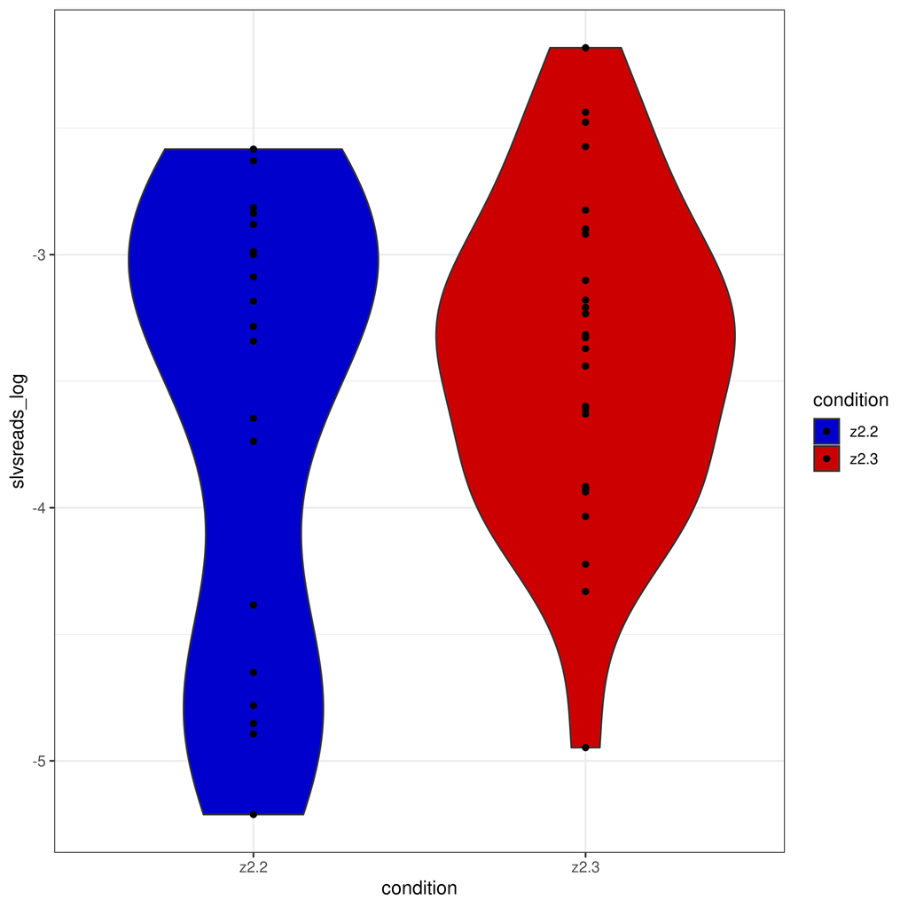

```r
lp_meta <- pData(lp_macrophage)
lp_meta[["slvsreads_log"]] <- log10(lp_meta[["slvsreads"]])
inf_values <- is.infinite(lp_meta[["slvsreads_log"]])
lp_meta[inf_values, "slvsreads_log"] <- -10

color_vector <- as.character(color_choices[["strain"]])
names(color_vector) <- names(color_choices[["strain"]])
color_vector <- color_vector[c("z2.2", "z2.3", "unknown")]
names(color_vector) <- c("z2.2", "z2.3", "none")
sl_violin <- ggplot(lp_meta,
                    aes(x = .data[["condition"]], y = .data[["slvsreads_log"]],
                        fill = .data[["condition"]])) +
  geom_violin() +
  geom_point() +
  scale_fill_manual(values = color_vector)
sl_violin
```

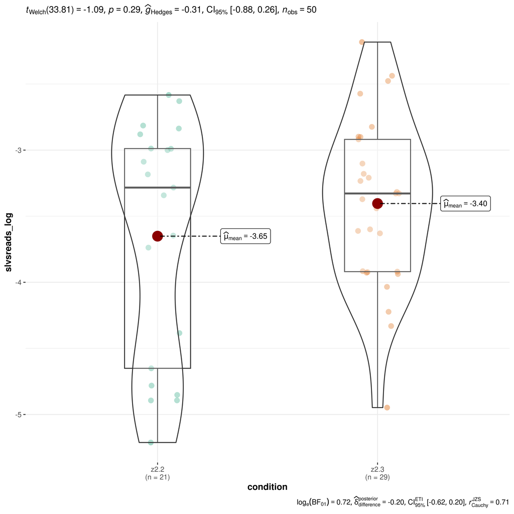

```r
ggstatsplot::ggbetweenstats(lp_meta, x = "condition", y = "slvsreads_log")
```

# 13 Save all data structures into one rda

```r
save(list = data_structures, file = glue("rda/tmrc2_data_structures-v{ver}.rda"))
```

```
## Error in save(list = data_structures, file = glue("rda/tmrc2_data_structures-v{ver}.rda")): objects 'lp_expt', 'lp_strain', 'lp_two_strains', 'lp_cf', 'lp_cf_known', 'lp_susceptibility_historical', 'lp_susceptibility', 'lp_zymo', 'new_snps' not found
```

**R version 4.3.1 (2023-06-16)**

**Platform:** x86_64-pc-linux-gnu (64-bit)

**locale:** *LC_CTYPE=en_US.UTF-8*, *LC_NUMERIC=C*, *LC_TIME=en_US.UTF-8*, *LC_COLLATE=en_US.UTF-8*, *LC_MONETARY=en_US.UTF-8*, *LC_MESSAGES=en_US.UTF-8*, *LC_PAPER=en_US.UTF-8*, *LC_NAME=C*, *LC_ADDRESS=C*, *LC_TELEPHONE=C*, *LC_MEASUREMENT=en_US.UTF-8* and *LC_IDENTIFICATION=C*

**attached base packages:** *splines*, *stats4*, *stats*, *graphics*, *grDevices*, *utils*, *datasets*, *methods* and *base*

**other attached packages:** *ruv(v.0.9.7.1)*, *lme4(v.1.1-35.1)*, *BiocParallel(v.1.34.2)*, *variancePartition(v.1.30.2)*, *org.Lpanamensis.MHOMCOL81L13.v46.eg.db(v.2020.07)*, *AnnotationDbi(v.1.62.2)*, *futile.logger(v.1.4.3)*, *EuPathDB(v.1.6.0)*, *GenomeInfoDbData(v.1.2.10)*, *dplyr(v.1.1.4)*, *Heatplus(v.3.8.0)*, *ggplot2(v.3.4.4)*, *hpgltools(v.1.0)*, *Matrix(v.1.6-4)*, *glue(v.1.7.0)*, *SummarizedExperiment(v.1.30.2)*, *GenomicRanges(v.1.52.1)*, *GenomeInfoDb(v.1.36.4)*, *IRanges(v.2.34.1)*, *S4Vectors(v.0.38.2)*, *MatrixGenerics(v.1.12.3)*, *matrixStats(v.1.2.0)*, *Biobase(v.2.60.0)* and *BiocGenerics(v.0.46.0)*

**loaded via a namespace (and not attached):** *bitops(v.1.0-7)*, *lubridate(v.1.9.3)*, *insight(v.0.19.7)*, *HDO.db(v.0.99.1)*, *httr(v.1.4.7)*, *RColorBrewer(v.1.1-3)*, *doParallel(v.1.0.17)*, *tools(v.4.3.1)*, *backports(v.1.4.1)*, *utf8(v.1.2.4)*, *R6(v.2.5.1)*, *statsExpressions(v.1.5.2)*, *lazyeval(v.0.2.2)*, *mgcv(v.1.9-1)*, *withr(v.2.5.2)*, *prettyunits(v.1.2.0)*, *gridExtra(v.2.3)*, *cli(v.3.6.2)*, *formatR(v.1.14)*, *AnnotationHubData(v.1.30.0)*, *sandwich(v.3.1-0)*, *prismatic(v.1.1.1)*, *labeling(v.0.4.3)*, *sass(v.0.4.8)*, *mvtnorm(v.1.2-4)*, *genefilter(v.1.82.1)*, *readr(v.2.1.4)*, *pbapply(v.1.7-2)*, *Rsamtools(v.2.16.0)*, *DOSE(v.3.26.2)*, *stringdist(v.0.9.12)*, *AnnotationForge(v.1.42.2)*, *limma(v.3.56.2)*, *RSQLite(v.2.3.4)*, *generics(v.0.1.3)*, *BiocIO(v.1.10.0)*, *gtools(v.3.9.5)*, *vroom(v.1.6.5)*, *zip(v.2.3.0)*, *GO.db(v.3.17.0)*, *fansi(v.1.0.6)*, *abind(v.1.4-5)*, *lifecycle(v.1.0.4)*, *multcomp(v.1.4-25)*, *yaml(v.2.3.8)*, *edgeR(v.3.42.4)*, *gplots(v.3.1.3)*, *biocViews(v.1.68.2)*, *qvalue(v.2.32.0)*, *BiocFileCache(v.2.8.0)*, *Rtsne(v.0.17)*, *paletteer(v.1.5.0)*, *grid(v.4.3.1)*, *blob(v.1.2.4)*, *promises(v.1.2.1)*, *crayon(v.1.5.2)*, *lattice(v.0.22-5)*, *cowplot(v.1.1.2)*, *GenomicFeatures(v.1.52.2)*, *annotate(v.1.78.0)*, *KEGGREST(v.1.40.1)*, *zeallot(v.0.1.0)*, *pillar(v.1.9.0)*, *knitr(v.1.45)*, *fgsea(v.1.26.0)*, *rjson(v.0.2.21)*, *boot(v.1.3-28.1)*, *estimability(v.1.4.1)*, *corpcor(v.1.6.10)*, *codetools(v.0.2-19)*, *fastmatch(v.1.1-4)*, *data.table(v.1.14.10)*, *vctrs(v.0.6.5)*, *png(v.0.1-8)*, *Rdpack(v.2.6)*, *testthat(v.3.2.1)*, *gtable(v.0.3.4)*, *rematch2(v.2.1.2)*, *datawizard(v.0.9.1)*, *cachem(v.1.0.8)*, *xfun(v.0.41)*, *openxlsx(v.4.2.5.2)*, *rbibutils(v.2.2.16)*, *S4Arrays(v.1.2.0)*, *mime(v.0.12)*, *correlation(v.0.8.4)*, *coda(v.0.19-4)*, *survival(v.3.5-7)*, *iterators(v.1.0.14)*, *TH.data(v.1.1-2)*, *directlabels(v.2023.8.25)*, *interactiveDisplayBase(v.1.38.0)*, *ellipsis(v.0.3.2)*, *nlme(v.3.1-164)*, *pbkrtest(v.0.5.2)*, *bit64(v.4.0.5)*, *progress(v.1.2.3)*, *EnvStats(v.2.8.1)*, *filelock(v.1.0.3)*, *rprojroot(v.2.0.4)*, *bslib(v.0.6.1)*, *KernSmooth(v.2.23-22)*, *colorspace(v.2.1-0)*, *DBI(v.1.2.0)*, *tidyselect(v.1.2.0)*, *emmeans(v.1.9.0)*, *bit(v.4.0.5)*, *compiler(v.4.3.1)*, *curl(v.5.2.0)*, *rvest(v.1.0.3)*, *graph(v.1.78.0)*, *BiocCheck(v.1.36.1)*, *xml2(v.1.3.6)*, *desc(v.1.4.3)*, *DelayedArray(v.0.26.7)*, *plotly(v.4.10.3)*, *bayestestR(v.0.13.1)*, *rtracklayer(v.1.60.1)*, *scales(v.1.3.0)*, *caTools(v.1.18.2)*, *remaCor(v.0.0.16)*, *quadprog(v.1.5-8)*, *RBGL(v.1.76.0)*, *rappdirs(v.0.3.3)*, *stringr(v.1.5.1)*, *digest(v.0.6.33)*, *minqa(v.1.2.6)*, *rmarkdown(v.2.25)*, *aod(v.1.3.3)*, *XVector(v.0.40.0)*, *RhpcBLASctl(v.0.23-42)*, *htmltools(v.0.5.7)*, *pkgconfig(v.2.0.3)*, *highr(v.0.10)*, *dbplyr(v.2.3.4)*, *fastmap(v.1.1.1)*, *rlang(v.1.1.3)*, *htmlwidgets(v.1.6.4)*, *shiny(v.1.8.0)*, *farver(v.2.1.1)*, *jquerylib(v.0.1.4)*, *zoo(v.1.8-12)*, *jsonlite(v.1.8.8)*, *GOSemSim(v.2.26.1)*, *RCurl(v.1.98-1.13)*, *magrittr(v.2.0.3)*, *patchwork(v.1.1.3)*, *parameters(v.0.21.3)*, *munsell(v.0.5.0)*, *Rcpp(v.1.0.11)*, *stringi(v.1.8.3)*, *brio(v.1.1.4)*, *zlibbioc(v.1.46.0)*, *MASS(v.7.3-60)*, *AnnotationHub(v.3.8.0)*, *plyr(v.1.8.9)*, *parallel(v.4.3.1)*, *ggrepel(v.0.9.4)*, *Biostrings(v.2.68.1)*, *pander(v.0.6.5)*, *hms(v.1.1.3)*, *locfit(v.1.5-9.8)*, *RUnit(v.0.4.32)*, *fastcluster(v.1.2.3)*, *effectsize(v.0.8.6)*, *reshape2(v.1.4.4)*, *biomaRt(v.2.56.1)*, *pkgload(v.1.3.3)*, *futile.options(v.1.0.1)*, *BiocVersion(v.3.17.1)*, *XML(v.3.99-0.16)*, *evaluate(v.0.23)*, *lambda.r(v.1.2.4)*, *BiocManager(v.1.30.22)*, *nloptr(v.2.0.3)*, *tzdb(v.0.4.0)*, *foreach(v.1.5.2)*, *httpuv(v.1.6.13)*, *MatrixModels(v.0.5-3)*, *BayesFactor(v.0.9.12-4.6)*, *tidyr(v.1.3.0)*, *purrr(v.1.0.2)*, *broom(v.1.0.5)*, *xtable(v.1.8-4)*, *restfulr(v.0.0.15)*, *later(v.1.3.2)*, *viridisLite(v.0.4.2)*, *OrganismDbi(v.1.42.0)*, *tibble(v.3.2.1)*, *ggstatsplot(v.0.12.1)*, *memoise(v.2.0.1)*, *GenomicAlignments(v.1.36.0)*, *timechange(v.0.2.0)*, *sva(v.3.48.0)* and *GSEABase(v.1.62.0)*

```r
message("This is hpgltools commit: ", get_git_commit())
```

```
## If you wish to reproduce this exact build of hpgltools, invoke the following:
```

```
## > git clone http://github.com/abelew/hpgltools.git
```

```
## > git reset 8224d622945a60e47938385e2b46b4b67dd656e4
```

```
## This is hpgltools commit: Wed Jan 10 11:42:53 2024 -0500: 8224d622945a60e47938385e2b46b4b67dd656e4
```

```r
message("Saving to ", savefile)
```

```
## Saving to 01datasets.rda.xz
```

```r
# tmp <- sm(saveme(filename = savefile))
```

```r
tmp <- loadme(filename = savefile)
```